# Activity2_Suicide

2024-08-06

## 1. Import and preprocess data

```r
data <- read.csv("master.csv", header = TRUE)

attach(data)
head(data)
```

```
##   country year    sex         age suicides_no population suicides.100k.pop
## 1 Albania 1987   male 15-24 years          21     312900              6.71
## 2 Albania 1987   male 35-54 years          16     308000              5.19
## 3 Albania 1987 female 15-24 years          14     289700              4.83
## 4 Albania 1987   male   75+ years           1      21800              4.59
## 5 Albania 1987   male 25-34 years           9     274300              3.28
## 6 Albania 1987 female   75+ years           1      35600              2.81
##   country.year HDI.for.year gdp_for_year.... gdp_per_capita....      generation
## 1  Albania1987           NA    2,156,624,900                796    Generation X
## 2  Albania1987           NA    2,156,624,900                796          Silent
## 3  Albania1987           NA    2,156,624,900                796    Generation X
## 4  Albania1987           NA    2,156,624,900                796 G.I. Generation
## 5  Albania1987           NA    2,156,624,900                796         Boomers
## 6  Albania1987           NA    2,156,624,900                796 G.I. Generation
```

```r
str(data)
```

```
## 'data.frame':    27820 obs. of  12 variables:
##  $ country           : chr  "Albania" "Albania" "Albania" "Albania" ...
##  $ year              : int  1987 1987 1987 1987 1987 1987 1987 1987 1987 1987 ...
##  $ sex               : chr  "male" "male" "female" "male" ...
##  $ age               : chr  "15-24 years" "35-54 years" "15-24 years" "75+ years" ...
##  $ suicides_no       : int  21 16 14 1 9 1 6 4 1 0 ...
##  $ population        : int  312900 308000 289700 21800 274300 35600 278800 257200 137500 311000 ...
##  $ suicides.100k.pop : num  6.71 5.19 4.83 4.59 3.28 2.81 2.15 1.56 0.73 0 ...
##  $ country.year      : chr  "Albania1987" "Albania1987" "Albania1987" "Albania1987" ...
##  $ HDI.for.year      : num  NA NA NA NA NA NA NA NA NA NA ...
##  $ gdp_for_year....  : chr  "2,156,624,900" "2,156,624,900" "2,156,624,900" "2,156,624,900" ...
##  $ gdp_per_capita....: int  796 796 796 796 796 796 796 796 796 796 ...
##  $ generation        : chr  "Generation X" "Silent" "Generation X" "G.I. Generation" ...
```

```r
dim(data)
```

```
## [1] 27820    12
```

### Rename columns

```r
data$gdp_for_year <- data$gdp_for_year....
data$gdp_for_year.... <- NULL

data$gdp_per_capita <- data$gdp_per_capita....
data$gdp_per_capita.... <- NULL
```

### Process missing values

```r
missing_values <- sapply(data, function(x) sum(is.na(x)))
print(missing_values)
```

```
##           country              year               sex               age
##                 0                 0                 0                 0
##       suicides_no        population suicides.100k.pop      country.year
##                 0                 0                 0                 0
##      HDI.for.year        generation      gdp_for_year    gdp_per_capita
##             19456                 0                 0                 0
```

The missing values of HDI.for.year account for about 70% of the dataset. Therefore, we decide to remove this variable. Moreover, country.year is combination string of country and year, which is redundant and suicides.100k.pop is suicides / (population / 100k), which includes our dependent variable suicides_no, so we also decide to remove those variables at first.

### Process unnecessary columns

```r
data_clean <- data
data_clean <- dplyr::select(data_clean, -HDI.for.year, -country.year, -suicides.100k.pop)
```

### Convert data types

```r
# Convert gdp_for_year to numeric after removing commas
data_clean <- data_clean %>%
mutate(gdp_for_year = as.numeric(gsub(",", "", gdp_for_year)))

str(data_clean)
```

```
## 'data.frame':    27820 obs. of  9 variables:
##  $ country       : chr  "Albania" "Albania" "Albania" "Albania" ...
##  $ year          : int  1987 1987 1987 1987 1987 1987 1987 1987 1987 1987 ...
##  $ sex           : chr  "male" "male" "female" "male" ...
##  $ age           : chr  "15-24 years" "35-54 years" "15-24 years" "75+ years" ...
##  $ suicides_no   : int  21 16 14 1 9 1 6 4 1 0 ...
##  $ population    : int  312900 308000 289700 21800 274300 35600 278800 257200 137500 311000 ...
##  $ generation    : chr  "Generation X" "Silent" "Generation X" "G.I. Generation" ...
##  $ gdp_for_year  : num  2.16e+09 2.16e+09 2.16e+09 2.16e+09 2.16e+09 ...
##  $ gdp_per_capita: int  796 796 796 796 796 796 796 796 796 796 ...
```

```r
detach(data)
attach(data_clean)
```

### Process duplicate rows

```r
duplicate_rows <- data_clean[duplicated(data_clean), ]
print(duplicate_rows)
```

```
## [1] country        year           sex            age            suicides_no
## [6] population     generation     gdp_for_year   gdp_per_capita
## <0 rows> (or 0-length row.names)
```

### Descriptive statistic

```r
summary(data_clean)
```

```
##    country               year          sex                age
##  Length:27820       Min.   :1985   Length:27820       Length:27820
##  Class :character   1st Qu.:1995   Class :character   Class :character
##  Mode  :character   Median :2002   Mode  :character   Mode  :character
##                     Mean   :2001
##                     3rd Qu.:2008
##                     Max.   :2016
##   suicides_no        population        generation         gdp_for_year
##  Min.   :    0.0   Min.   :     278   Length:27820       Min.   :4.692e+07
##  1st Qu.:    3.0   1st Qu.:   97498   Class :character   1st Qu.:8.985e+09
##  Median :   25.0   Median :  430150   Mode  :character   Median :4.811e+10
##  Mean   :  242.6   Mean   : 1844794                      Mean   :4.456e+11
##  3rd Qu.:  131.0   3rd Qu.: 1486143                      3rd Qu.:2.602e+11
##  Max.   :22338.0   Max.   :43805214                      Max.   :1.812e+13
##  gdp_per_capita
##  Min.   :   251
##  1st Qu.:  3447
##  Median :  9372
##  Mean   : 16866
##  3rd Qu.: 24874
##  Max.   :126352
```

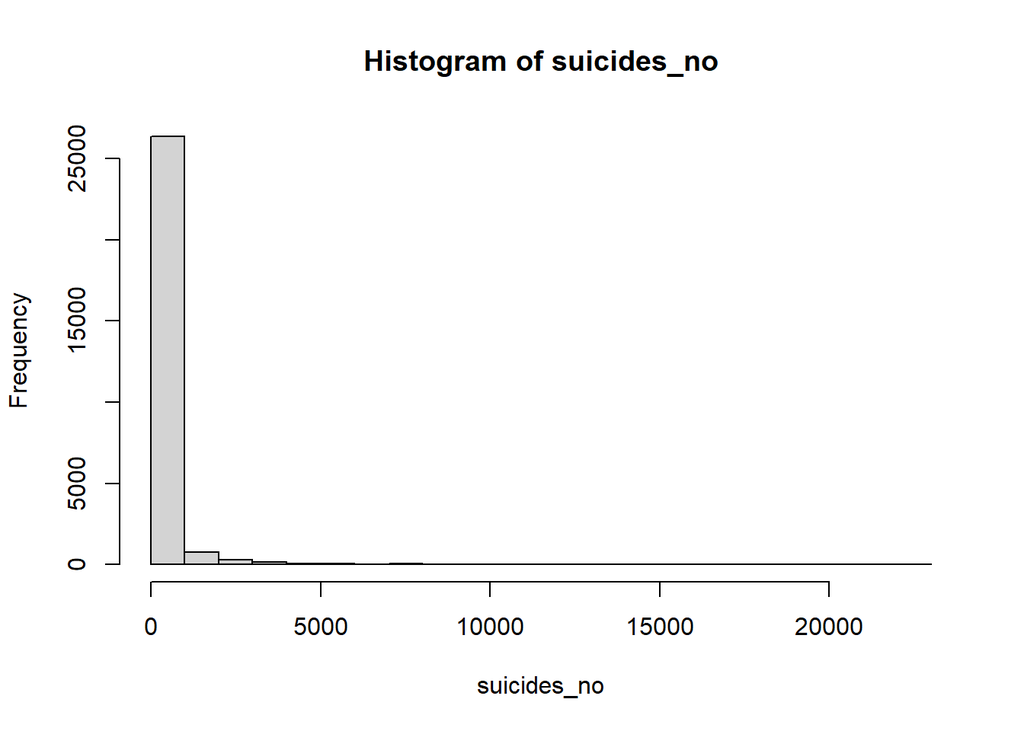

```r
# Descriptive statistics for the 'suicides_no' column
hist(suicides_no, breaks = 30)
```

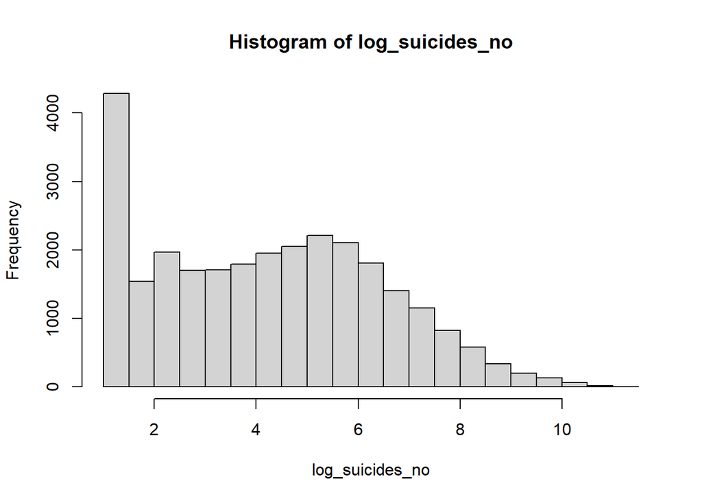

```r
log_suicides_no <- log(suicides_no + 1) + 1

hist(log_suicides_no, breaks = 30)
```

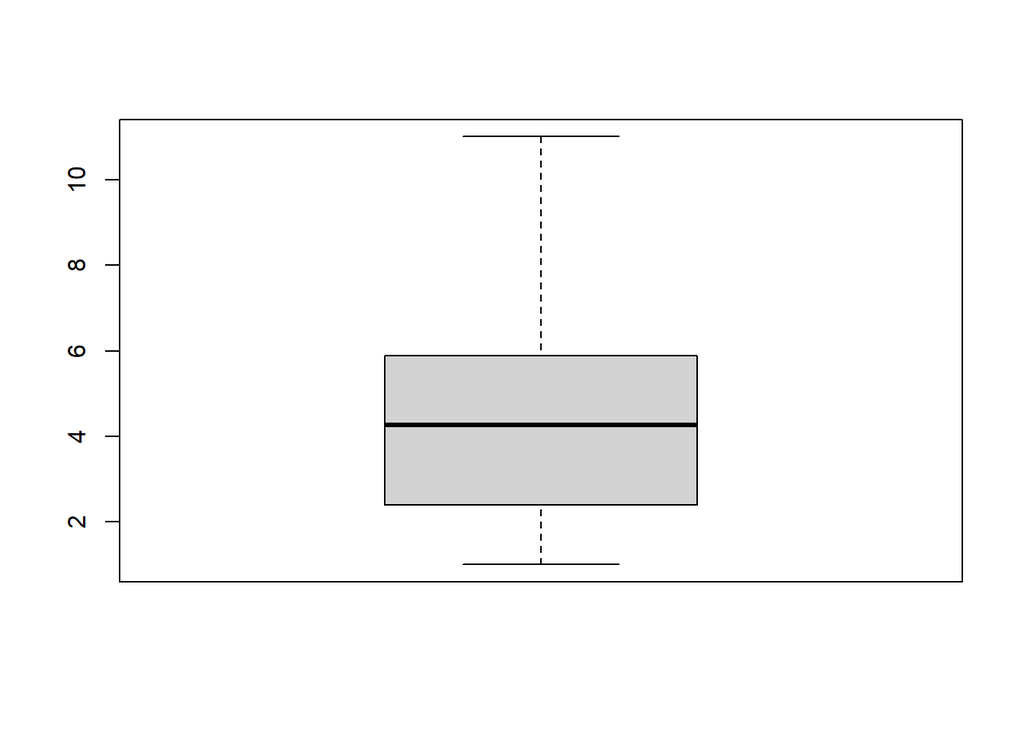

```r
boxplot(log_suicides_no)
```

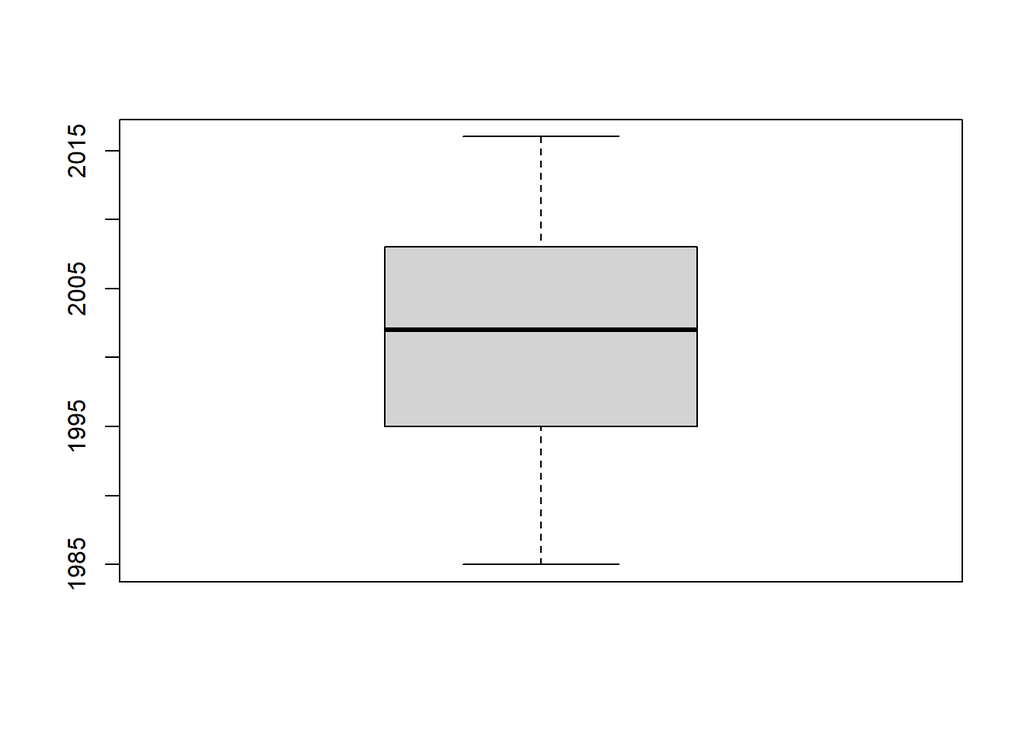

```r
# Descriptive statistics for the 'year' column
boxplot(year)
```

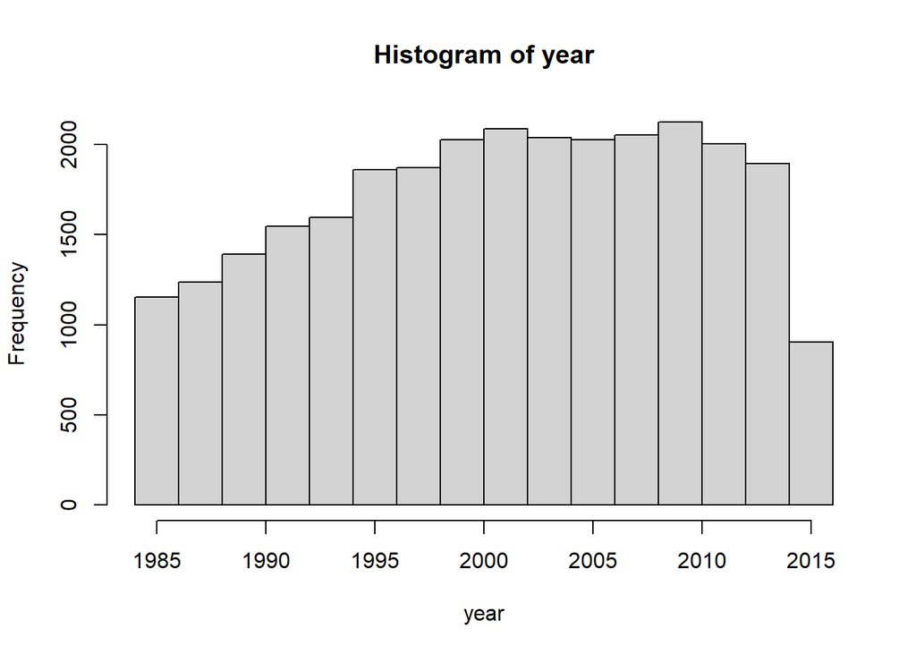

```r
hist(year, breaks = 20)
```

The most frequent years in the dataset are between 2000 and 2010, indicating that these years have the highest number of records related to suicides.

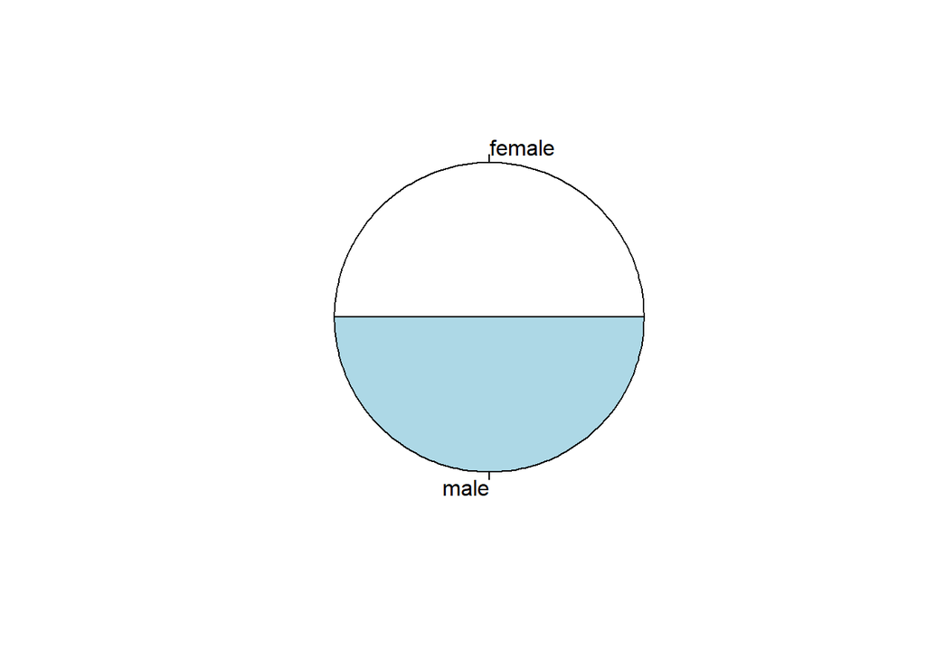

```r
# Descriptive statistics for 'sex' column
pie(table(sex))
```

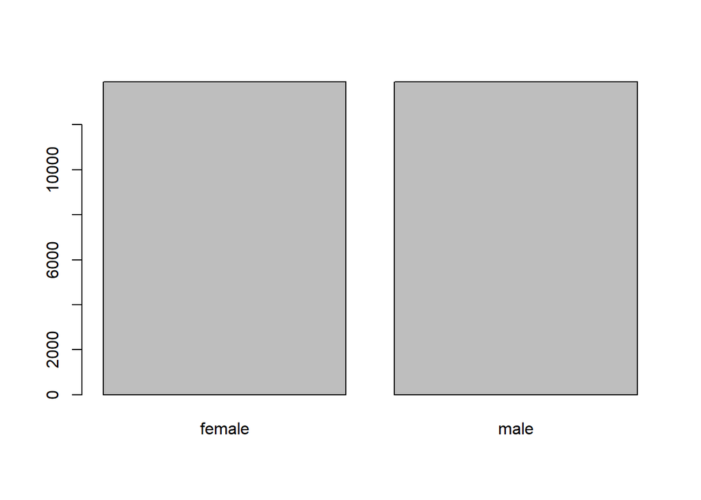

```r
barplot(table(sex))
```

The suicide records distributed evenly among male and female.

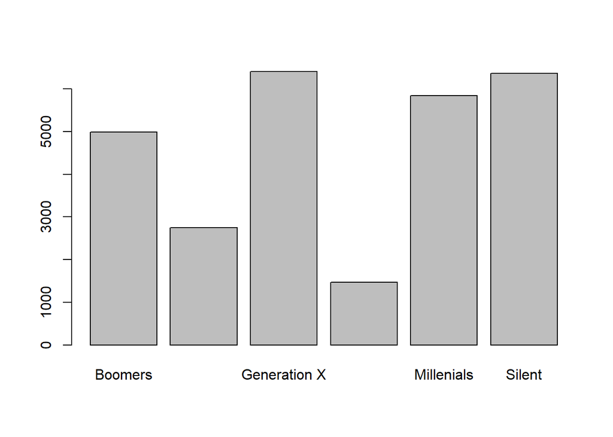

```r
# Descriptive Statistics for 'generation' and 'age'
barplot(table(generation))
```

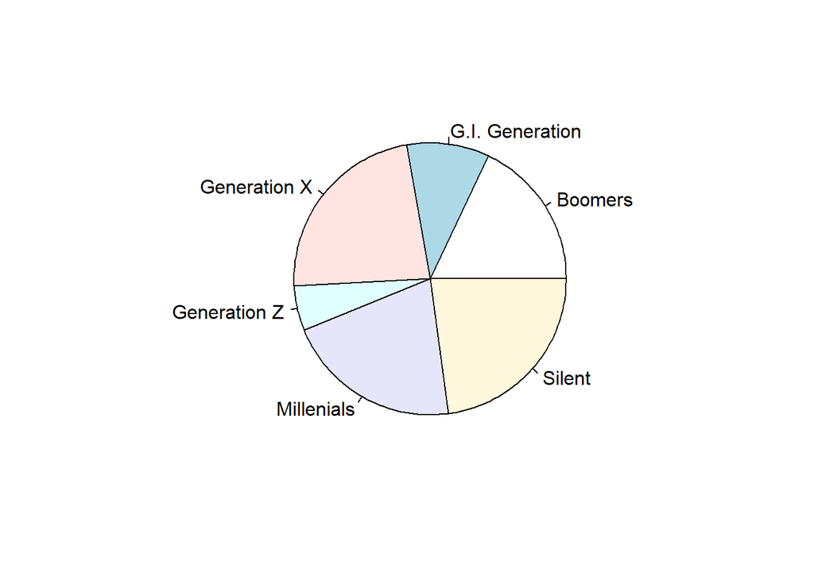

```r
pie(table(generation))
```

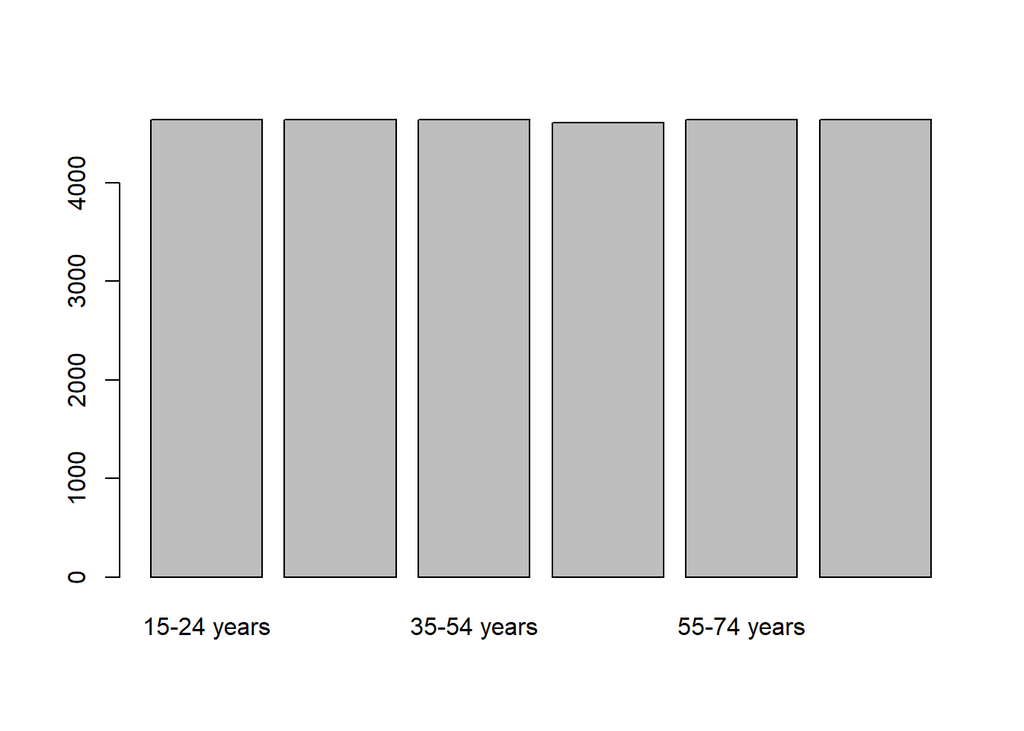

```r
barplot(table(age))
```

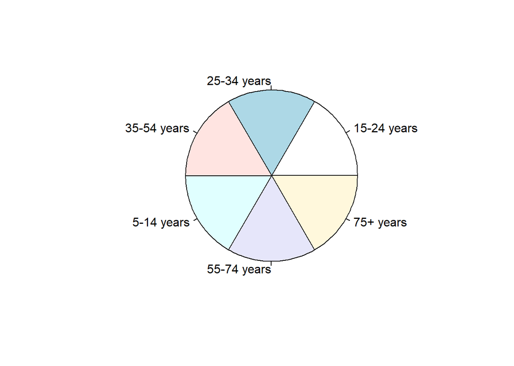

```r
pie(table(age))
```

Based on the observation, the suicides cases distributed evenly among different ages. The number of suicides records is the lowest in the Generation Z group.

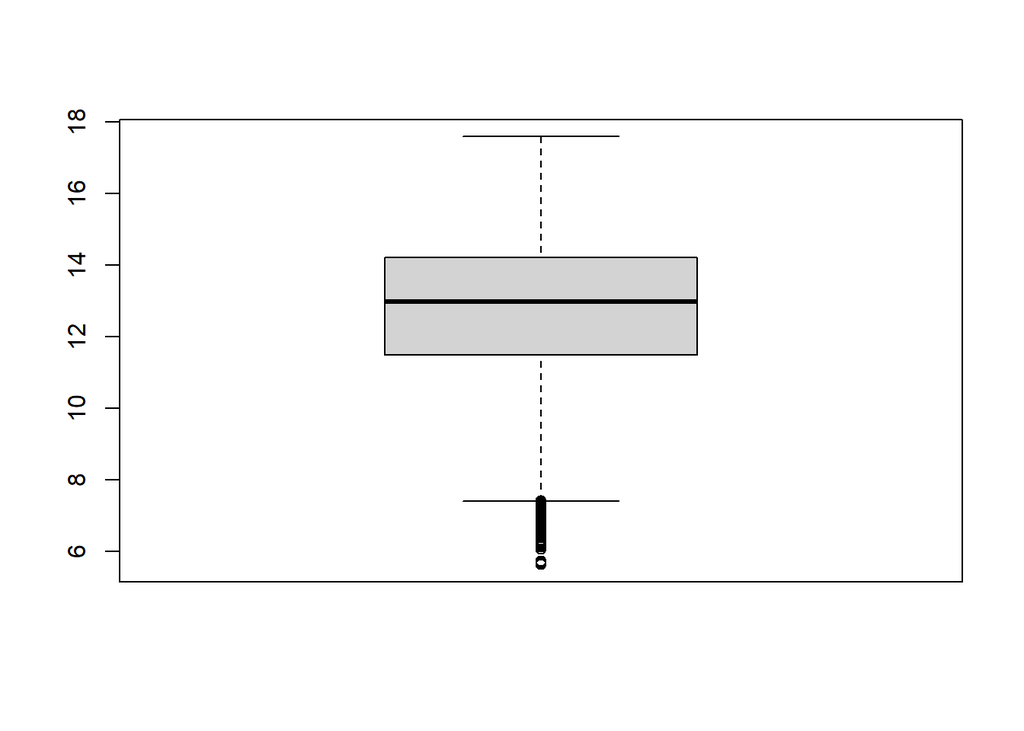

```r
# Descriptive statistics for 'population'
boxplot(log(population))
```

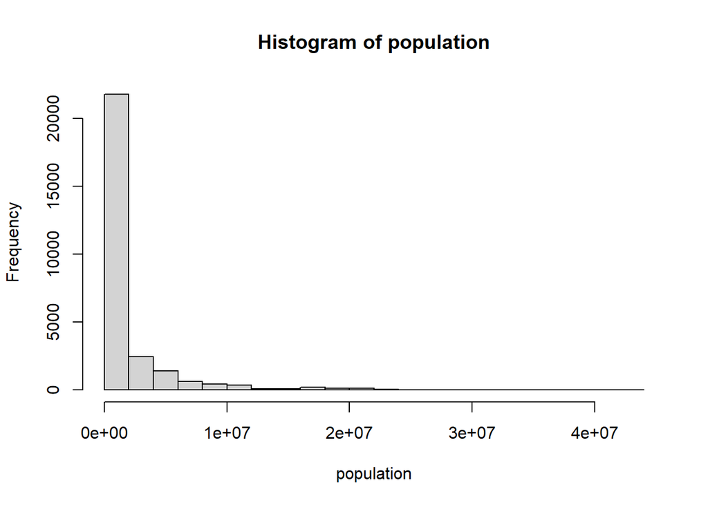

```r
hist(population, breaks = 30)
```

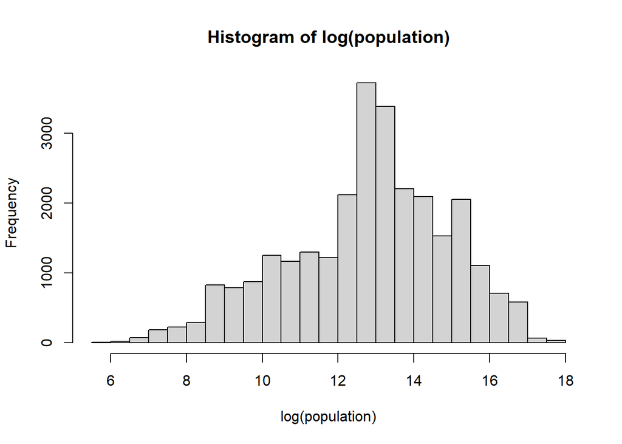

```r
hist(log(population), breaks = 30)
```

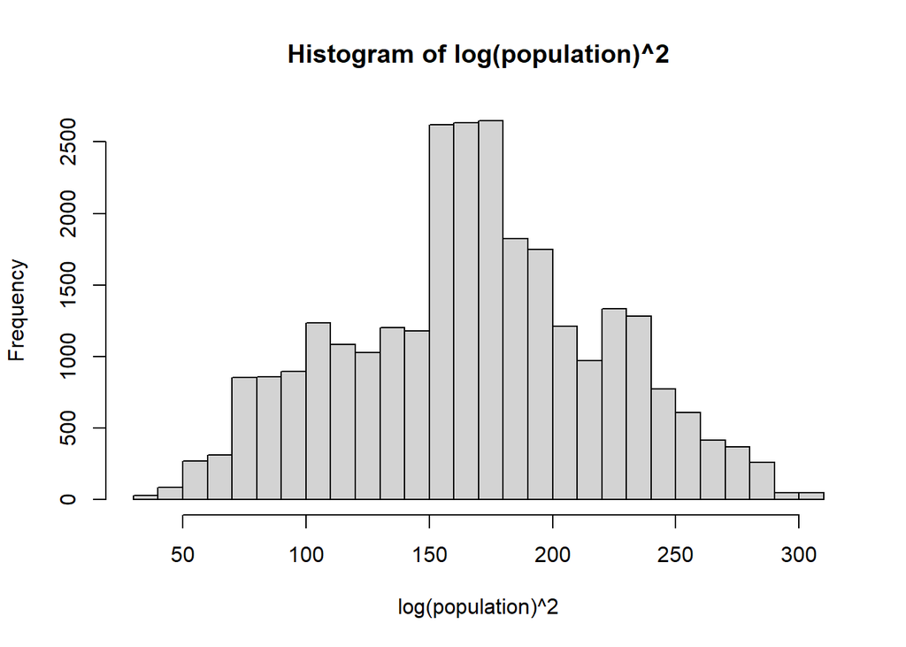

```r
hist(log(population)^2, breaks = 30)
```

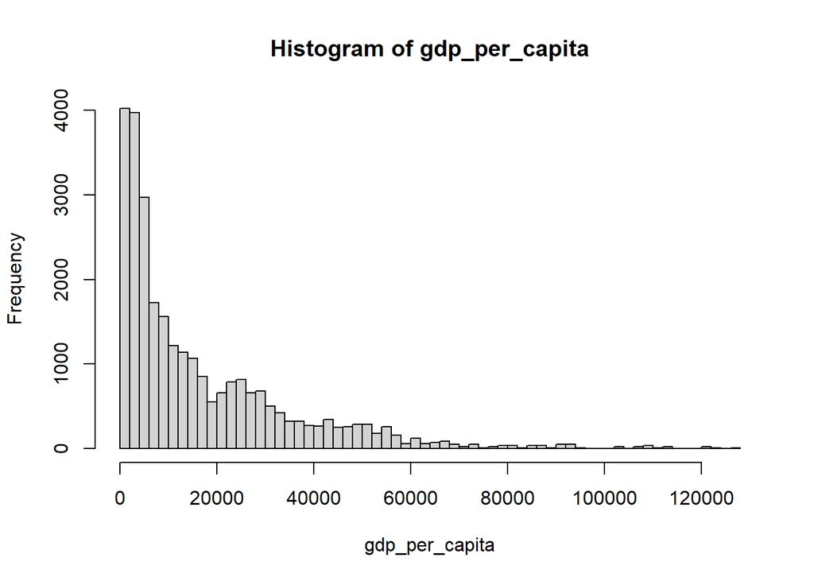

```r
# Descriptive statistics for 'gdp_per_capita'
hist(gdp_per_capita, breaks = 50)
```

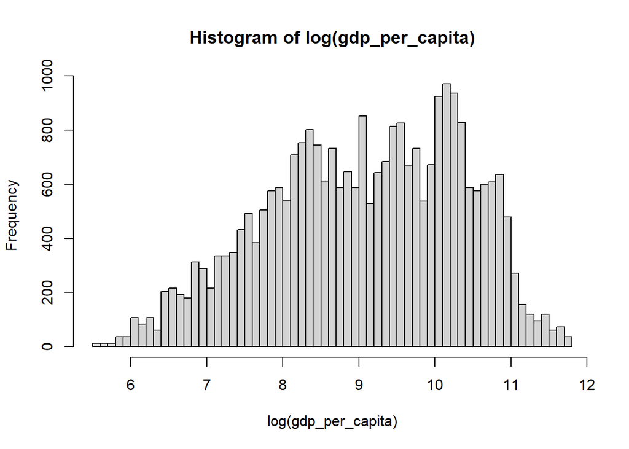

```r
hist(log(gdp_per_capita), breaks = 50)
```

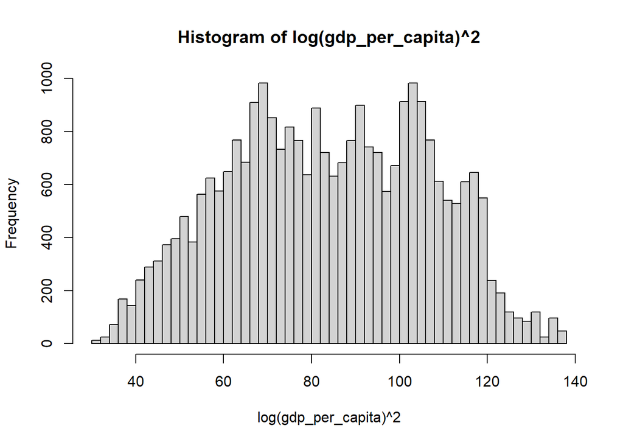

```r
hist(log(gdp_per_capita)^2, breaks = 50)
```

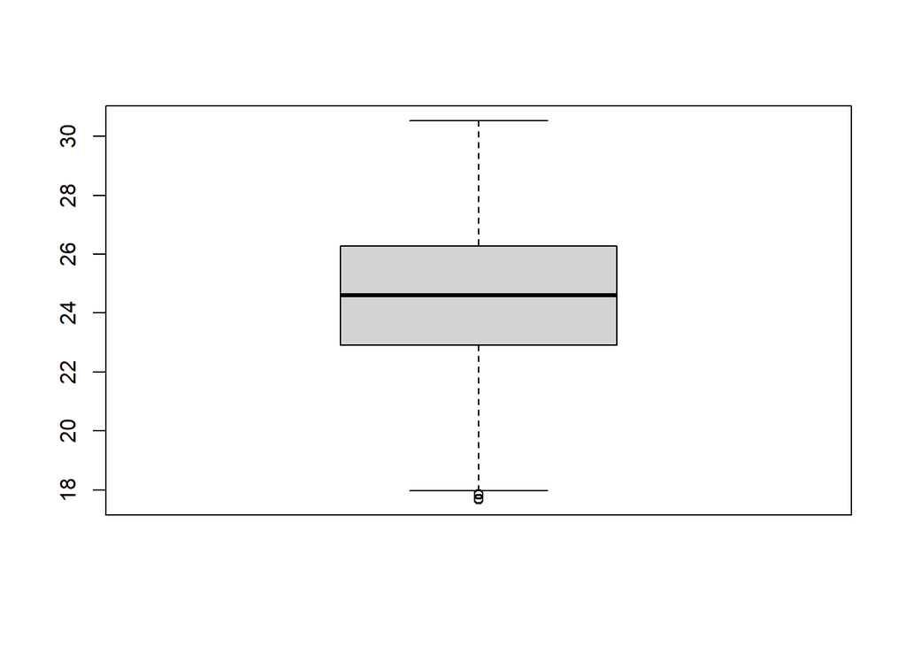

```r
# Descriptive statistics for 'gdp_for_year'
boxplot(log(gdp_for_year))
```

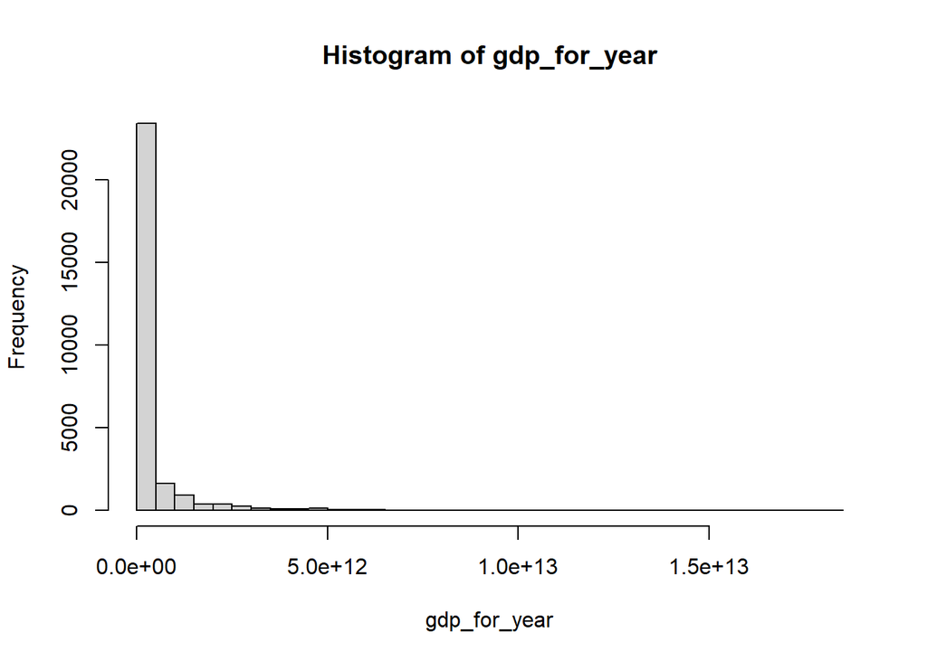

```r
hist(gdp_for_year, breaks = 30)
```

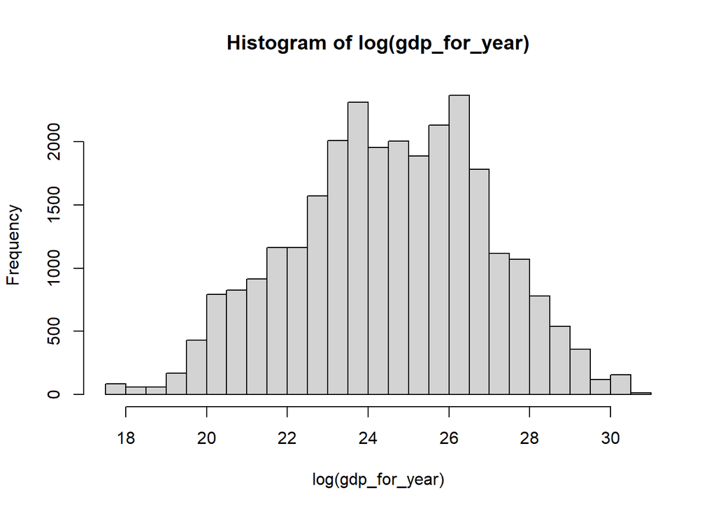

```r
hist(log(gdp_for_year), breaks = 30)
```

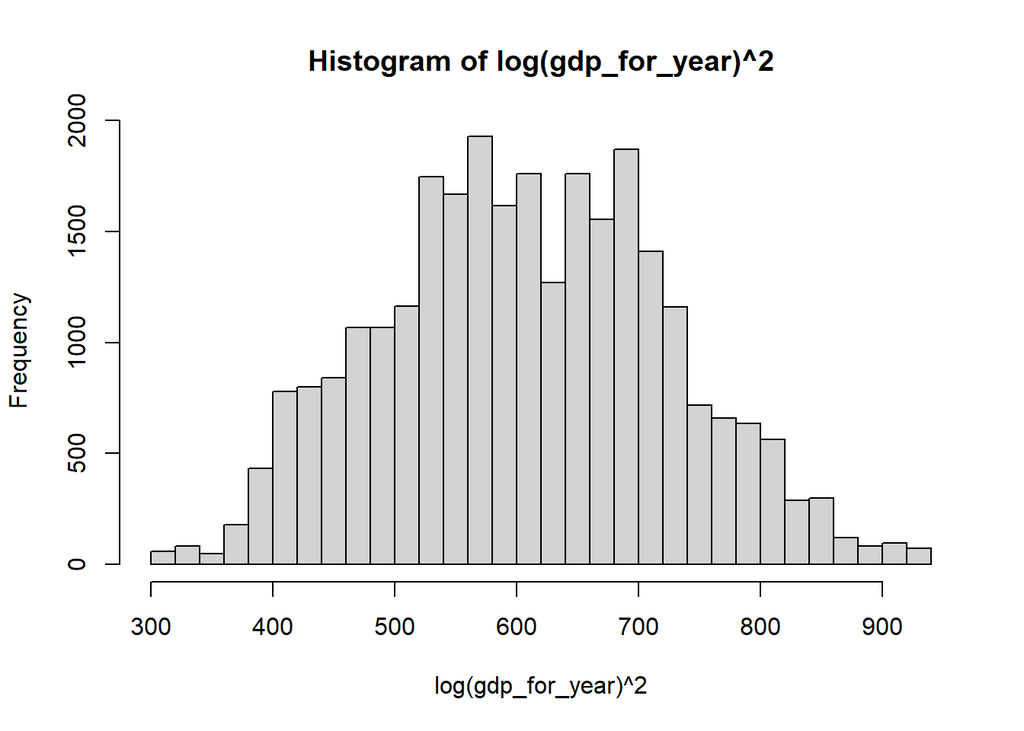

```r
hist(log(gdp_for_year)^2, breaks = 30)
```

### Relationship between response variable and predictors

```r
log_suicides_no <- log(suicides_no + 1) + 1
log_population_sq <- log(population)^2
log_gdp_per_capita_sq <- log(gdp_per_capita)^2
log_gdp_for_year <- log(gdp_for_year)
```

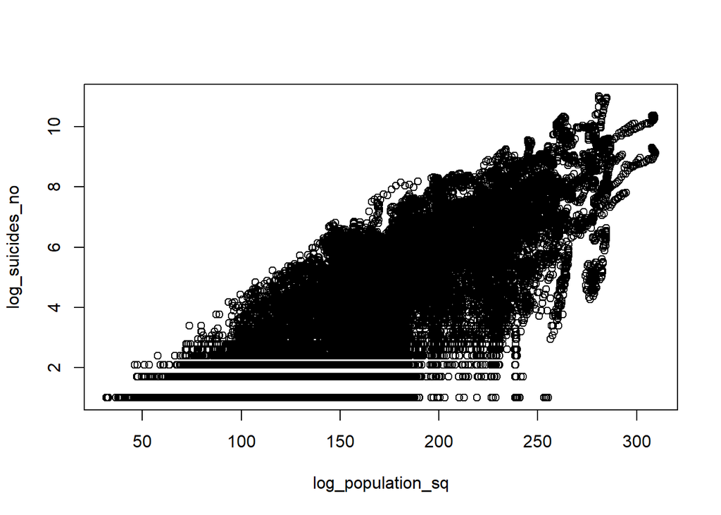

```r
plot(log_suicides_no ~ log_population_sq)
```

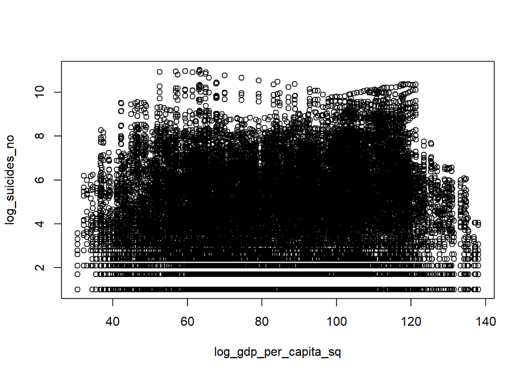

```r
plot(log_suicides_no ~ log_gdp_per_capita_sq)
```

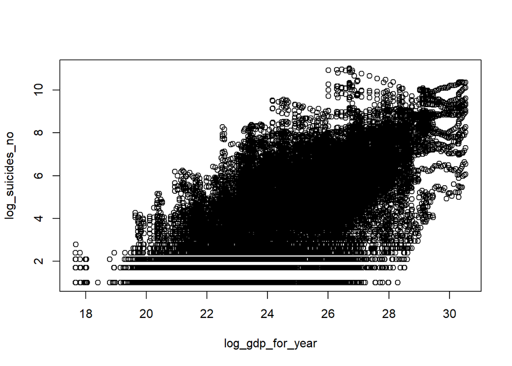

```r
plot(log_suicides_no ~ log_gdp_for_year)
```

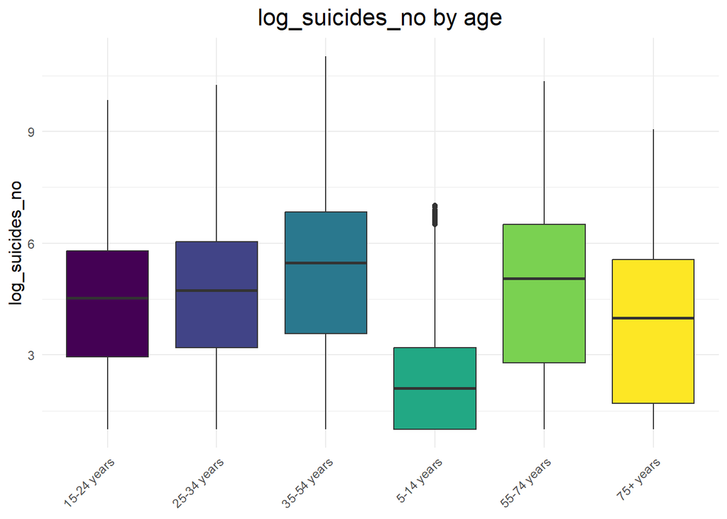

```r
ggplot(data_clean, aes(x = age, y = log_suicides_no, fill = age)) +
  geom_boxplot() +
  scale_fill_viridis_d() +  # Use viridis color palette
  labs(title = "log_suicides_no by age",
       y = "log_suicides_no",
       x = NULL) +  # Remove x-axis label as it's redundant
  theme_minimal() +
  theme(
    axis.text.x = element_text(angle = 45, hjust = 1, vjust = 1),
    legend.position = "none",  # Remove legend as colors are already on x-axis
    plot.title = element_text(hjust = 0.5, size = 16),
    axis.title.y = element_text(size = 12)
  )
```

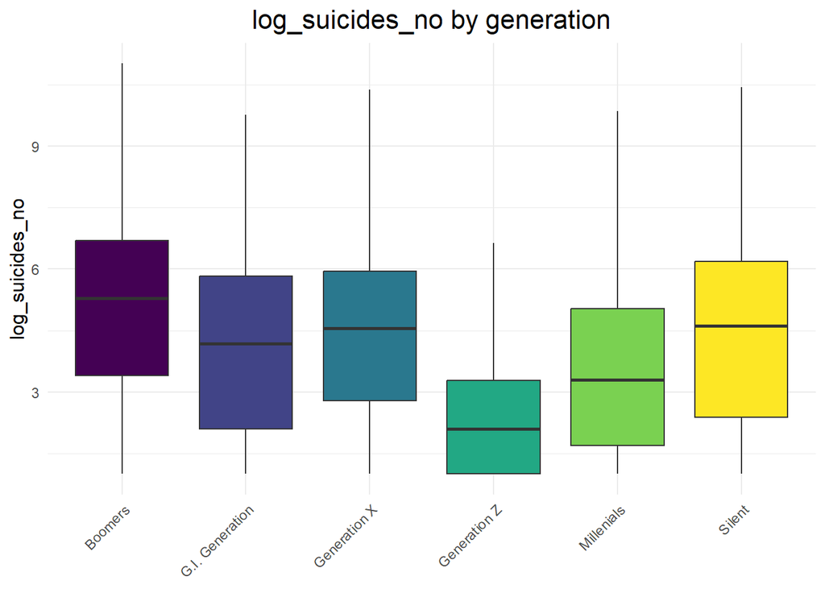

```r
ggplot(data_clean, aes(x = generation, y = log_suicides_no, fill = generation)) +
  geom_boxplot() +
  scale_fill_viridis_d() +  # Use viridis color palette
  labs(title = "log_suicides_no by generation",
       y = "log_suicides_no",
       x = NULL) +  # Remove x-axis label as it's redundant
  theme_minimal() +
  theme(
    axis.text.x = element_text(angle = 45, hjust = 1, vjust = 1),
    legend.position = "none",  # Remove legend as colors are already on x-axis
    plot.title = element_text(hjust = 0.5, size = 16),
    axis.title.y = element_text(size = 12)
  )
```

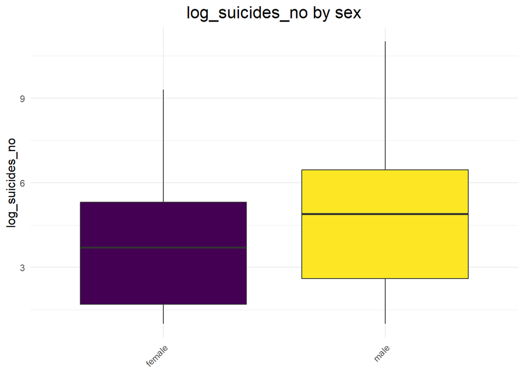

```r
ggplot(data_clean, aes(x = sex, y = log_suicides_no, fill = sex)) +
  geom_boxplot() +
  scale_fill_viridis_d() +  # Use viridis color palette
  labs(title = "log_suicides_no by sex",
       y = "log_suicides_no",
       x = NULL) +  # Remove x-axis label as it's redundant
  theme_minimal() +
  theme(
    axis.text.x = element_text(angle = 45, hjust = 1, vjust = 1),
    legend.position = "none",  # Remove legend as colors are already on x-axis
    plot.title = element_text(hjust = 0.5, size = 16),
    axis.title.y = element_text(size = 12)
  )
```

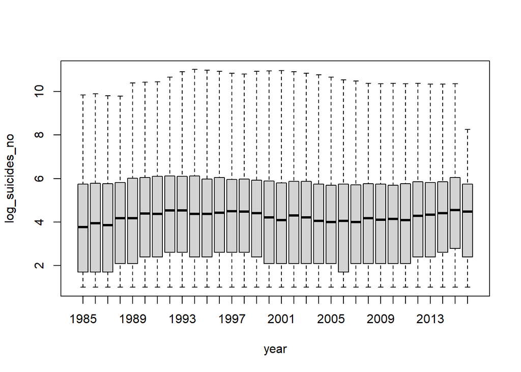

```r
boxplot(log_suicides_no ~ year)
```

### Normalize variables

```r
# Process 'suicides_no' column
data_clean$log_suicides_no <- log(suicides_no + 1) + 1
data_clean$suicides_no <- NULL
```

```r
# Process 'gdp_per_capita' column
data_clean$transform_gdp_per_capita <- log(gdp_per_capita)^2
data_clean$gdp_per_capita <- NULL
```

```r
# Process 'population' column
data_clean$transform_population <- log(population)^2
data_clean$population <- NULL
```

```r
# Process 'gdp_per_capita' column
data_clean$transform_gdp_for_year <- log(gdp_for_year)
data_clean$gdp_for_year <- NULL
```

### Process variables

```r
# Process 'year' column
max(data_clean$year)
```

```
## [1] 2016
```

```r
data_clean$year <- data_clean$year - 1985 + 1
```

```r
# # Create dummy variables for the 'country' column

data_clean$regionEurope <- ifelse(data_clean$country %in% c("Austria", "Iceland", "Netherlands", "Belgium", "Bulgaria", "France", "Greece", "Ireland", "Italy", "Luxembourg", "Malta", "Norway", "Portugal", "Romania", "Spain", "Sweden", "United Kingdom", "Ukraine", "Finland", "Switzerland", "Serbia", "Slovenia", "Slovakia", "Albania", "Denmark", "Estonia", "Latvia", "Lithuania", "Belarus", "Croatia", "Czech Republic", "Germany", "Hungary", "Poland", "San Marino", "Bosnia and Herzegovina"), 1, 0)

data_clean$regionAsia <- ifelse(data_clean$country %in% c("Israel", "Japan", "Republic of Korea", "Singapore", "Turkmenistan", "Thailand", "Russian Federation", "Kazakhstan", "Kyrgyzstan", "Armenia", "Azerbaijan", "Philippines", "Cyprus", "Qatar", "Sri Lanka", "Maldives", "Turkey", "United Arab Emirates", "Oman", "Bahrain", "Uzbekistan", "Georgia", "Macau"), 1, 0)

data_clean$regionAfrica <- ifelse(data_clean$country %in% c("Mauritius", "South Africa", "Seychelles", "Cabo Verde"), 1, 0)

data_clean$regionNorthAmerica <- ifelse(data_clean$country %in% c("Canada", "Costa Rica", "Guatemala", "Mexico", "Puerto Rico", "United States", "Belize", "Saint Lucia", "Antigua and Barbuda", "Trinidad and Tobago", "Panama", "Saint Vincent and Grenadines", "Cuba", "El Salvador", "Bahamas", "Jamaica", "Saint Kitts and Nevis", "Dominica"), 1, 0)

data_clean$regionSouthAmerica <- ifelse(data_clean$country %in% c("Argentina", "Brazil", "Chile", "Colombia", "Ecuador", "Paraguay", "Suriname", "Uruguay", "Guyana"), 1, 0)

data_clean$regionOceania <- ifelse(data_clean$country %in% c("Australia", "New Zealand", "Fiji", "Kiribati", "Montenegro"), 1, 0)

# Remove the 'country' column after creating 'region'
data_clean$country <- NULL
```

```r
data_clean$sexMale <- ifelse(data_clean$sex == "male", 1, 0)
data_clean$sex <- NULL
```

```r
data_clean$geneX <- ifelse(data_clean$generation == "Generation X", 1, 0)
data_clean$geneMillenials <- ifelse(data_clean$generation == "Millenials", 1, 0)
data_clean$geneBoomers <- ifelse(data_clean$generation == "Boomers", 1, 0)
data_clean$geneSilent <- ifelse(data_clean$generation == "Silent", 1, 0)
data_clean$generation <- NULL
# The other generation would be G.I. Generation
```

```r
data_clean$Age15to24 <- ifelse(data_clean$age == "15-24 years", 1, 0)
data_clean$Age25to34 <- ifelse(data_clean$age == "25-34 years", 1, 0)
data_clean$Age35to54 <- ifelse(data_clean$age == "35-54 years", 1, 0)
data_clean$Age55to74 <- ifelse(data_clean$age == "55-74 years", 1, 0)
data_clean$age <- NULL
#The other generation would be 75+ years
```

### Process outliers

```r
# Calculate Cook's distance
model <- lm(log_suicides_no ~ ., data = data_clean)
cooksD <- cooks.distance(model)

# Identify influential observations
influential <- cooksD[(cooksD > (3/length(cooksD)))]

# Extract the indices of influential observations
outliers <- as.numeric(names(influential))

# Remove influential observations to clean the data
data_clean <- data_clean[-outliers, ]
```

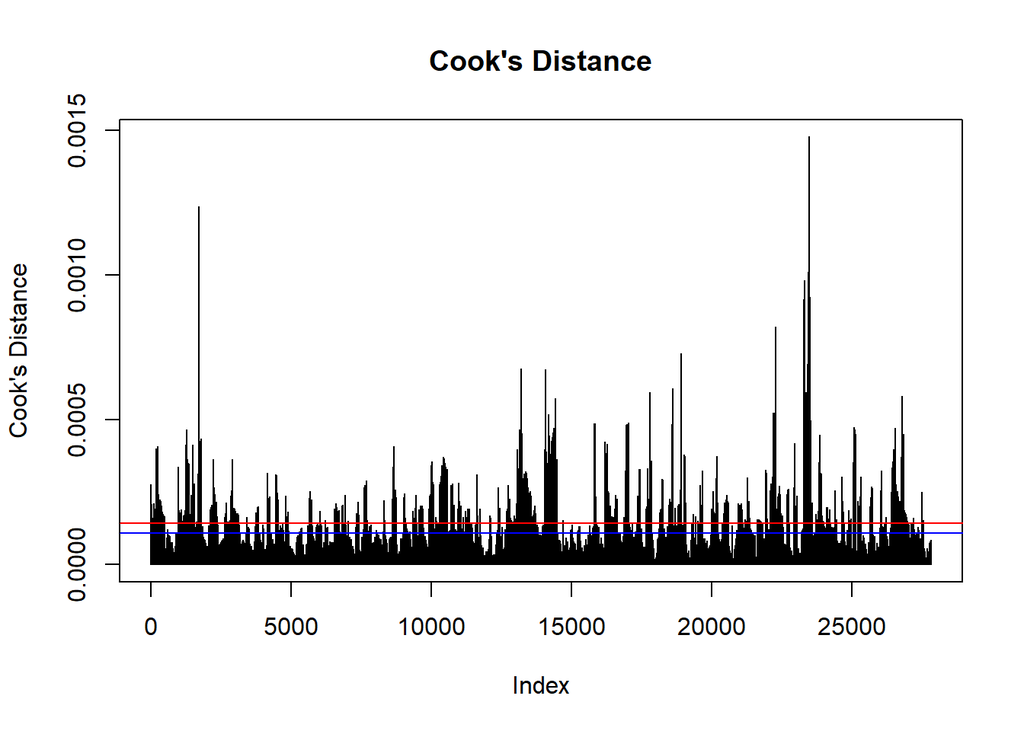

```r
plot(cooksD, type = "h", main = "Cook's Distance", ylab = "Cook's Distance")
abline(h = 4 / length(cooksD), col = "red") # original threshold line
abline(h = 3/ length(cooksD), col = "blue") # custom threshold line
```

### Analyze preprocessed dataset

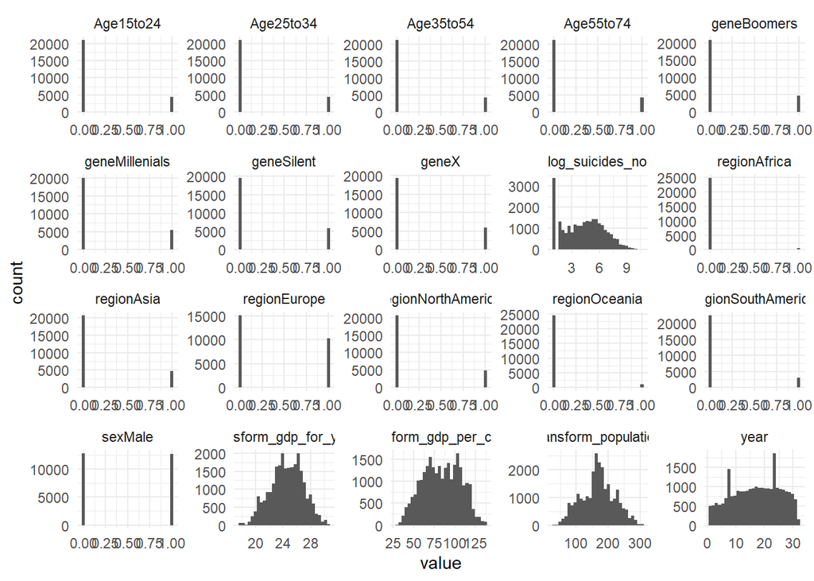

```r
# Visualize preprocessed dataset
data_clean %>%
  gather(key = "variable", value = "value") %>%
  ggplot(aes(x = value)) +
  facet_wrap(~ variable, scales = "free") +
  geom_histogram(bins = 30) +
  theme_minimal()
```

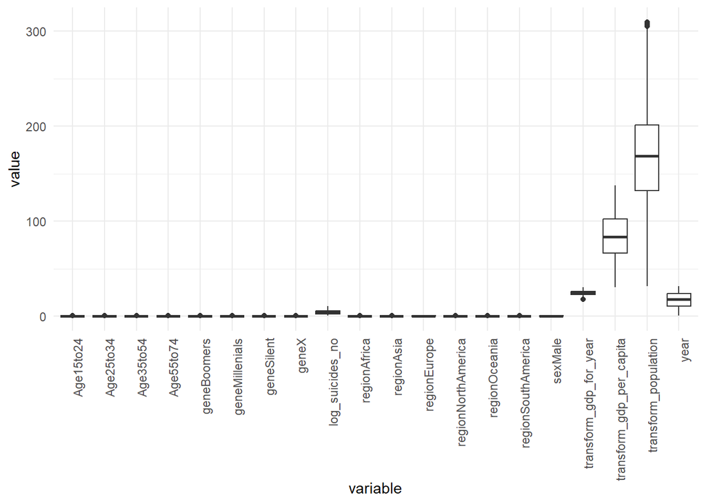

```r
data_clean %>%
  gather(key = "variable", value = "value") %>%
  ggplot(aes(x = variable, y = value)) +
  geom_boxplot() +
  theme_minimal() +
  theme(axis.text.x = element_text(angle = 90, hjust = 1))
```

```r
# Descriptive statistics for the preprocessed dataset
summary(data_clean)
```

```
##       year      log_suicides_no  transform_gdp_per_capita transform_population
##  Min.   : 1.0   Min.   : 1.000   Min.   : 30.53           Min.   : 31.67
##  1st Qu.:11.0   1st Qu.: 2.386   1st Qu.: 66.53           1st Qu.:132.28
##  Median :18.0   Median : 4.401   Median : 83.89           Median :168.83
##  Mean   :17.2   Mean   : 4.314   Mean   : 83.97           Mean   :168.29
##  3rd Qu.:24.0   3rd Qu.: 5.934   3rd Qu.:102.60           3rd Qu.:201.41
##  Max.   :32.0   Max.   :10.671   Max.   :137.99           Max.   :309.59
##  transform_gdp_for_year  regionEurope      regionAsia      regionAfrica
##  Min.   :17.66          Min.   :0.0000   Min.   :0.0000   Min.   :0.00000
##  1st Qu.:22.95          1st Qu.:0.0000   1st Qu.:0.0000   1st Qu.:0.00000
##  Median :24.59          Median :0.0000   Median :0.0000   Median :0.00000
##  Mean   :24.54          Mean   :0.4073   Mean   :0.1877   Mean   :0.02165
##  3rd Qu.:26.27          3rd Qu.:1.0000   3rd Qu.:0.0000   3rd Qu.:0.00000
##  Max.   :30.53          Max.   :1.0000   Max.   :1.0000   Max.   :1.00000
##  regionNorthAmerica regionSouthAmerica regionOceania        sexMale
##  Min.   :0.0000     Min.   :0.0000     Min.   :0.00000   Min.   :0.0000
##  1st Qu.:0.0000     1st Qu.:0.0000     1st Qu.:0.00000   1st Qu.:0.0000
##  Median :0.0000     Median :0.0000     Median :0.00000   Median :0.0000
##  Mean   :0.1913     Mean   :0.1185     Mean   :0.03741   Mean   :0.4971
##  3rd Qu.:0.0000     3rd Qu.:0.0000     3rd Qu.:0.00000   3rd Qu.:1.0000
##  Max.   :1.0000     Max.   :1.0000     Max.   :1.00000   Max.   :1.0000
##      geneX        geneMillenials    geneBoomers       geneSilent
##  Min.   :0.0000   Min.   :0.0000   Min.   :0.0000   Min.   :0.000
##  1st Qu.:0.0000   1st Qu.:0.0000   1st Qu.:0.0000   1st Qu.:0.000
##  Median :0.0000   Median :0.0000   Median :0.0000   Median :0.000
##  Mean   :0.2369   Mean   :0.2139   Mean   :0.1856   Mean   :0.231
##  3rd Qu.:0.0000   3rd Qu.:0.0000   3rd Qu.:0.0000   3rd Qu.:0.000
##  Max.   :1.0000   Max.   :1.0000   Max.   :1.0000   Max.   :1.000
##    Age15to24        Age25to34        Age35to54        Age55to74
##  Min.   :0.0000   Min.   :0.0000   Min.   :0.0000   Min.   :0.0000
##  1st Qu.:0.0000   1st Qu.:0.0000   1st Qu.:0.0000   1st Qu.:0.0000
##  Median :0.0000   Median :0.0000   Median :0.0000   Median :0.0000
##  Mean   :0.1756   Mean   :0.1752   Mean   :0.1694   Mean   :0.1693
##  3rd Qu.:0.0000   3rd Qu.:0.0000   3rd Qu.:0.0000   3rd Qu.:0.0000
##  Max.   :1.0000   Max.   :1.0000   Max.   :1.0000   Max.   :1.0000
```

## 2. Split data to train and test

```r
set.seed(1)
sample_size <- floor(0.8 * nrow(data_clean))
train_indices <- sample(seq_len(nrow(data_clean)), size = sample_size)
data_train <- data_clean[train_indices, ]
data_test <- data_clean[-train_indices, ]
detach(data_clean)
attach(data_train)
```

## 3. Build model

### Check multicollinearity

```r
model = lm(log_suicides_no ~ ., data = data_train)
summary(model)
```

```
##
## Call:
## lm(formula = log_suicides_no ~ ., data = data_train)
##
## Residuals:
##      Min       1Q   Median       3Q      Max
## -2.64250 -0.55326  0.03595  0.59620  2.21050
##
## Coefficients:
##                            Estimate Std. Error t value Pr(>|t|)
## (Intercept)              -7.0165081  0.1861314 -37.697  < 2e-16 ***
## year                      0.0060499  0.0007992   7.570 3.88e-14 ***
## transform_gdp_per_capita -0.0154307  0.0007505 -20.561  < 2e-16 ***
## transform_population      0.0222043  0.0004848  45.802  < 2e-16 ***
## transform_gdp_for_year    0.3028174  0.0126812  23.879  < 2e-16 ***
## regionEurope              0.7731988  0.0341066  22.670  < 2e-16 ***
## regionAsia                0.3415597  0.0359580   9.499  < 2e-16 ***
## regionAfrica              0.1990702  0.0507310   3.924 8.74e-05 ***
## regionNorthAmerica        0.2105835  0.0347610   6.058 1.40e-09 ***
## regionSouthAmerica        0.3464502  0.0377073   9.188  < 2e-16 ***
## regionOceania             0.6888137  0.0442557  15.564  < 2e-16 ***
## sexMale                   1.0909626  0.0118003  92.452  < 2e-16 ***
## geneX                    -1.1212766  0.0283997 -39.482  < 2e-16 ***
## geneMillenials           -1.5562038  0.0271608 -57.296  < 2e-16 ***
## geneBoomers              -0.5826200  0.0290184 -20.078  < 2e-16 ***
## geneSilent                0.2050384  0.0220915   9.281  < 2e-16 ***
## Age15to24                 1.7095972  0.0217454  78.619  < 2e-16 ***
## Age25to34                 1.6204107  0.0230932  70.168  < 2e-16 ***
## Age35to54                 1.5167949  0.0273872  55.383  < 2e-16 ***
## Age55to74                 0.8103206  0.0229191  35.356  < 2e-16 ***
## ---
## Signif. codes:  0 '***' 0.001 '**' 0.01 '*' 0.05 '.' 0.1 ' ' 1
##
## Residual standard error: 0.8383 on 20336 degrees of freedom
## Multiple R-squared:  0.8523, Adjusted R-squared:  0.8522
## F-statistic:  6178 on 19 and 20336 DF,  p-value: < 2.2e-16
```

```r
car::vif(model)
```

```
##                     year transform_gdp_per_capita     transform_population
##                 1.298947                 8.329852                18.450468
##   transform_gdp_for_year             regionEurope               regionAsia
##                25.791534                 8.139897                 5.688080
##             regionAfrica       regionNorthAmerica       regionSouthAmerica
##                 1.601222                 5.423623                 4.317677
##            regionOceania                  sexMale                    geneX
##                 2.031497                 1.008424                 4.233884
##           geneMillenials              geneBoomers               geneSilent
##                 3.607707                 3.687870                 2.504603
##                Age15to24                Age25to34                Age35to54
##                 2.022694                 2.213491                 3.064101
##                Age55to74
##                 2.131516
```

```r
model = lm(log_suicides_no ~ . -transform_gdp_for_year , data = data_train)
summary(model)
```

```
##
## Call:
## lm(formula = log_suicides_no ~ . - transform_gdp_for_year, data = data_train)
##
## Residuals:
##      Min       1Q   Median       3Q      Max
## -2.82752 -0.54409  0.04794  0.59913  2.17075
##
## Coefficients:
##                            Estimate Std. Error t value Pr(>|t|)
## (Intercept)              -2.6967901  0.0444369 -60.688  < 2e-16 ***
## year                      0.0079290  0.0008063   9.834  < 2e-16 ***
## transform_gdp_per_capita  0.0008968  0.0003137   2.859  0.00425 **
## transform_population      0.0333798  0.0001282 260.280  < 2e-16 ***
## regionEurope              0.8579694  0.0343928  24.946  < 2e-16 ***
## regionAsia                0.4288735  0.0362688  11.825  < 2e-16 ***
## regionAfrica              0.2318317  0.0514173   4.509 6.56e-06 ***
## regionNorthAmerica        0.2586477  0.0351849   7.351 2.04e-13 ***
## regionSouthAmerica        0.4420493  0.0380153  11.628  < 2e-16 ***
## regionOceania             0.7601260  0.0447685  16.979  < 2e-16 ***
## sexMale                   1.1135775  0.0119257  93.376  < 2e-16 ***
## geneX                    -1.3720106  0.0267541 -51.282  < 2e-16 ***
## geneMillenials           -1.8271888  0.0250195 -73.031  < 2e-16 ***
## geneBoomers              -0.7538001  0.0285098 -26.440  < 2e-16 ***
## geneSilent                0.2026564  0.0223983   9.048  < 2e-16 ***
## Age15to24                 1.6633846  0.0219601  75.746  < 2e-16 ***
## Age25to34                 1.5537470  0.0232425  66.849  < 2e-16 ***
## Age35to54                 1.2363789  0.0250857  49.286  < 2e-16 ***
## Age55to74                 0.5578103  0.0206164  27.057  < 2e-16 ***
## ---
## Signif. codes:  0 '***' 0.001 '**' 0.01 '*' 0.05 '.' 0.1 ' ' 1
##
## Residual standard error: 0.8499 on 20337 degrees of freedom
## Multiple R-squared:  0.8482, Adjusted R-squared:  0.8481
## F-statistic:  6313 on 18 and 20337 DF,  p-value: < 2.2e-16
```

```r
car::vif(model)
```

```
##                     year transform_gdp_per_capita     transform_population
##                 1.286351                 1.415712                 1.256022
##             regionEurope               regionAsia             regionAfrica
##                 8.051713                 5.629264                 1.600051
##       regionNorthAmerica       regionSouthAmerica            regionOceania
##                 5.405438                 4.269006                 2.022247
##                  sexMale                    geneX           geneMillenials
##                 1.001929                 3.655131                 2.977923
##              geneBoomers               geneSilent                Age15to24
##                 3.462813                 2.504552                 2.006674
##                Age25to34                Age35to54                Age55to74
##                 2.181143                 2.500763                 1.677774
```

```r
cor(data_train$log_suicides_no, data_train$regionEurope)
```

```
## [1] 0.2131889
```

```r
model_regionEurope = lm(regionEurope ~ . -transform_gdp_for_year -log_suicides_no, data = data_train)
summary(model_regionEurope)
```

```
##
## Call:
## lm(formula = regionEurope ~ . - transform_gdp_for_year - log_suicides_no,
##     data = data_train)
##
## Residuals:
##      Min       1Q   Median       3Q      Max
## -0.92698 -0.00949  0.03285  0.07471  0.19593
##
## Coefficients:
##                            Estimate Std. Error  t value Pr(>|t|)
## (Intercept)               7.460e-01  7.397e-03  100.853  < 2e-16 ***
## year                     -8.614e-04  1.643e-04   -5.243 1.59e-07 ***
## transform_gdp_per_capita  4.117e-04  6.389e-05    6.444 1.19e-10 ***
## transform_population      1.000e-03  2.519e-05   39.704  < 2e-16 ***
## regionAsia               -9.226e-01  3.581e-03 -257.651  < 2e-16 ***
## regionAfrica             -8.647e-01  8.552e-03 -101.107  < 2e-16 ***
## regionNorthAmerica       -8.983e-01  3.433e-03 -261.658  < 2e-16 ***
## regionSouthAmerica       -9.222e-01  4.273e-03 -215.805  < 2e-16 ***
## regionOceania            -9.026e-01  6.577e-03 -137.237  < 2e-16 ***
## sexMale                   1.685e-03  2.431e-03    0.693 0.488260
## geneX                    -1.367e-02  5.454e-03   -2.506 0.012205 *
## geneMillenials           -1.224e-02  5.100e-03   -2.400 0.016384 *
## geneBoomers              -4.090e-03  5.813e-03   -0.704 0.481700
## geneSilent                8.824e-03  4.566e-03    1.932 0.053327 .
## Age15to24                -1.430e-02  4.476e-03   -3.194 0.001404 **
## Age25to34                -1.838e-02  4.737e-03   -3.880 0.000105 ***
## Age35to54                -3.377e-02  5.109e-03   -6.611 3.93e-11 ***
## Age55to74                -2.412e-02  4.200e-03   -5.743 9.45e-09 ***
## ---
## Signif. codes:  0 '***' 0.001 '**' 0.01 '*' 0.05 '.' 0.1 ' ' 1
##
## Residual standard error: 0.1733 on 20338 degrees of freedom
## Multiple R-squared:  0.8758, Adjusted R-squared:  0.8757
## F-statistic:  8436 on 17 and 20338 DF,  p-value: < 2.2e-16
```

```r
model = lm(log_suicides_no ~ . -transform_gdp_for_year -regionEurope, data = data_train)
summary(model)
```

```
##
## Call:
## lm(formula = log_suicides_no ~ . - transform_gdp_for_year - regionEurope,
##     data = data_train)
##
## Residuals:
##      Min       1Q   Median       3Q      Max
## -2.77886 -0.55459  0.05403  0.60832  2.23842
##
## Coefficients:
##                            Estimate Std. Error t value Pr(>|t|)
## (Intercept)              -2.0567292  0.0368312 -55.842  < 2e-16 ***
## year                      0.0071900  0.0008180   8.790  < 2e-16 ***
## transform_gdp_per_capita  0.0012501  0.0003181   3.930 8.54e-05 ***
## transform_population      0.0342378  0.0001254 272.986  < 2e-16 ***
## regionAsia               -0.3627247  0.0178302 -20.343  < 2e-16 ***
## regionAfrica             -0.5100124  0.0425811 -11.977  < 2e-16 ***
## regionNorthAmerica       -0.5120456  0.0170935 -29.955  < 2e-16 ***
## regionSouthAmerica       -0.3491385  0.0212766 -16.410  < 2e-16 ***
## regionOceania            -0.0142660  0.0327471  -0.436    0.663
## sexMale                   1.1150233  0.0121064  92.102  < 2e-16 ***
## geneX                    -1.3837385  0.0271555 -50.956  < 2e-16 ***
## geneMillenials           -1.8376929  0.0253952 -72.364  < 2e-16 ***
## geneBoomers              -0.7573088  0.0289416 -26.167  < 2e-16 ***
## geneSilent                0.2102268  0.0227358   9.247  < 2e-16 ***
## Age15to24                 1.6511175  0.0222874  74.083  < 2e-16 ***
## Age25to34                 1.5379793  0.0235861  65.207  < 2e-16 ***
## Age35to54                 1.2074024  0.0254387  47.463  < 2e-16 ***
## Age55to74                 0.5371167  0.0209120  25.685  < 2e-16 ***
## ---
## Signif. codes:  0 '***' 0.001 '**' 0.01 '*' 0.05 '.' 0.1 ' ' 1
##
## Residual standard error: 0.8628 on 20338 degrees of freedom
## Multiple R-squared:  0.8436, Adjusted R-squared:  0.8434
## F-statistic:  6451 on 17 and 20338 DF,  p-value: < 2.2e-16
```

```r
car::vif(model)
```

```
##                     year transform_gdp_per_capita     transform_population
##                 1.284615                 1.412827                 1.165669
##               regionAsia             regionAfrica       regionNorthAmerica
##                 1.320168                 1.064831                 1.237978
##       regionSouthAmerica            regionOceania                  sexMale
##                 1.297614                 1.049945                 1.001905
##                    geneX           geneMillenials              geneBoomers
##                 3.654003                 2.977079                 3.462729
##               geneSilent                Age15to24                Age25to34
##                 2.504092                 2.005668                 2.179530
##                Age35to54                Age55to74
##                 2.495401                 1.675058
```

### Variable selection (Stepwise)

```r
modFull = lm(log_suicides_no ~ . -transform_gdp_for_year -regionEurope, data = data_train)
modZero = lm(log_suicides_no ~ 1, data = data_train)
modInter = lm(log_suicides_no ~ year + transform_population + regionAsia + regionNorthAmerica + sexMale + geneBoomers + Age25to34, data = data_train)
```

```r
modelAIC = MASS::stepAIC(modFull, direction = "backward", scope = list(lower = modZero, upper = modFull), k = 2)
```

```
## Start:  AIC=-5990.09
## log_suicides_no ~ (year + transform_gdp_per_capita + transform_population +
##     transform_gdp_for_year + regionEurope + regionAsia + regionAfrica +
##     regionNorthAmerica + regionSouthAmerica + regionOceania +
##     sexMale + geneX + geneMillenials + geneBoomers + geneSilent +
##     Age15to24 + Age25to34 + Age35to54 + Age55to74) - transform_gdp_for_year -
##     regionEurope
##
##                            Df Sum of Sq   RSS     AIC
## - regionOceania             1         0 15140 -5991.9
## <none>                                  15140 -5990.1
## - transform_gdp_per_capita  1        11 15151 -5976.6
## - year                      1        58 15198 -5914.9
## - geneSilent                1        64 15204 -5906.7
## - regionAfrica              1       107 15247 -5849.0
## - regionSouthAmerica        1       200 15340 -5724.4
## - regionAsia                1       308 15448 -5582.0
## - Age55to74                 1       491 15631 -5342.3
## - geneBoomers               1       510 15650 -5318.1
## - regionNorthAmerica        1       668 15808 -5113.2
## - Age35to54                 1      1677 16817 -3853.7
## - geneX                     1      1933 17073 -3546.3
## - Age25to34                 1      3165 18305 -2127.6
## - geneMillenials            1      3898 19038 -1328.4
## - Age15to24                 1      4086 19226 -1129.0
## - sexMale                   1      6315 21455  1104.1
## - transform_population      1     55475 70615 25354.2
##
## Step:  AIC=-5991.9
## log_suicides_no ~ year + transform_gdp_per_capita + transform_population +
##     regionAsia + regionAfrica + regionNorthAmerica + regionSouthAmerica +
##     sexMale + geneX + geneMillenials + geneBoomers + geneSilent +
##     Age15to24 + Age25to34 + Age35to54 + Age55to74
##
##                            Df Sum of Sq   RSS     AIC
## <none>                                  15140 -5991.9
## - transform_gdp_per_capita  1        12 15152 -5978.4
## - year                      1        58 15198 -5916.5
## - geneSilent                1        64 15204 -5908.6
## - regionAfrica              1       107 15247 -5850.8
## - regionSouthAmerica        1       202 15342 -5723.7
## - regionAsia                1       313 15453 -5577.7
## - Age55to74                 1       491 15631 -5344.3
## - geneBoomers               1       510 15650 -5319.8
## - regionNorthAmerica        1       683 15823 -5095.9
## - Age35to54                 1      1677 16817 -3855.6
## - geneX                     1      1933 17073 -3547.9
## - Age25to34                 1      3165 18305 -2129.6
## - geneMillenials            1      3899 19039 -1329.6
## - Age15to24                 1      4085 19226 -1131.0
## - sexMale                   1      6315 21456  1102.9
## - transform_population      1     55699 70839 25416.6
```

```r
summary(modelAIC)
```

```
##
## Call:
## lm(formula = log_suicides_no ~ year + transform_gdp_per_capita +
##     transform_population + regionAsia + regionAfrica + regionNorthAmerica +
##     regionSouthAmerica + sexMale + geneX + geneMillenials + geneBoomers +
##     geneSilent + Age15to24 + Age25to34 + Age35to54 + Age55to74,
##     data = data_train)
##
## Residuals:
##      Min       1Q   Median       3Q      Max
## -2.77804 -0.55479  0.05352  0.60894  2.23968
##
## Coefficients:
##                            Estimate Std. Error t value Pr(>|t|)
## (Intercept)              -2.0587721  0.0365307 -56.357  < 2e-16 ***
## year                      0.0071976  0.0008178   8.801  < 2e-16 ***
## transform_gdp_per_capita  0.0012538  0.0003180   3.943 8.09e-05 ***
## transform_population      0.0342412  0.0001252 273.541  < 2e-16 ***
## regionAsia               -0.3615952  0.0176403 -20.498  < 2e-16 ***
## regionAfrica             -0.5086993  0.0424735 -11.977  < 2e-16 ***
## regionNorthAmerica       -0.5108360  0.0168662 -30.288  < 2e-16 ***
## regionSouthAmerica       -0.3479795  0.0211092 -16.485  < 2e-16 ***
## sexMale                   1.1150594  0.0121059  92.109  < 2e-16 ***
## geneX                    -1.3837826  0.0271548 -50.959  < 2e-16 ***
## geneMillenials           -1.8377777  0.0253939 -72.371  < 2e-16 ***
## geneBoomers              -0.7573298  0.0289410 -26.168  < 2e-16 ***
## geneSilent                0.2101417  0.0227345   9.243  < 2e-16 ***
## Age15to24                 1.6510224  0.0222859  74.084  < 2e-16 ***
## Age25to34                 1.5379131  0.0235851  65.207  < 2e-16 ***
## Age35to54                 1.2072322  0.0254352  47.463  < 2e-16 ***
## Age55to74                 0.5370362  0.0209108  25.682  < 2e-16 ***
## ---
## Signif. codes:  0 '***' 0.001 '**' 0.01 '*' 0.05 '.' 0.1 ' ' 1
##
## Residual standard error: 0.8628 on 20339 degrees of freedom
## Multiple R-squared:  0.8436, Adjusted R-squared:  0.8434
## F-statistic:  6854 on 16 and 20339 DF,  p-value: < 2.2e-16
```

## 4. Hypothesis testing

### Durbin_Watson test for autocorrelation

```r
lmtest::dwtest(modelAIC)
```

```
##
##  Durbin-Watson test
##
## data:  modelAIC
## DW = 1.9835, p-value = 0.119
## alternative hypothesis: true autocorrelation is greater than 0
```

### Shapiro-Wilk test for normality

```r
# Use Shapiro-Wilk test to test for normality of the residuals
set.seed(22) # For reproducibility
subsample_residuals <- sample(residuals(modelAIC), size = 5000)
shapiro.test(subsample_residuals)
```

```
##
##  Shapiro-Wilk normality test
##
## data:  subsample_residuals
## W = 0.99452, p-value = 7.183e-13
```

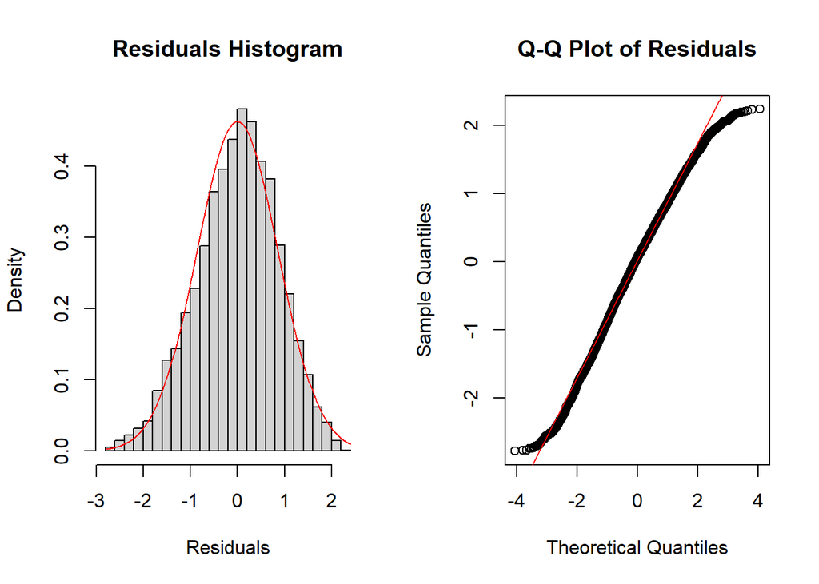

```r
# Plot residuals to visually check for normality
par(mfrow=c(1,2))

hist_residuals <- residuals(modelAIC)
hist(hist_residuals, main = "Residuals Histogram", xlab = "Residuals", breaks = 30, probability = TRUE)

mean_residuals <- mean(hist_residuals)
sd_residuals <- sd(hist_residuals)
curve(dnorm(x, mean = mean_residuals, sd = sd_residuals), col = "red", add = TRUE)

qqnorm(hist_residuals, main = "Q-Q Plot of Residuals")
qqline(hist_residuals, col = "red")
```

### Studentized Breusch-Pagan test for heteroscedasticity

```r
bp_test <- lmtest::bptest(modelAIC)
print(bp_test)
```

```
##
##  studentized Breusch-Pagan test
##
## data:  modelAIC
## BP = 3230.8, df = 16, p-value < 2.2e-16
```

### Box-Cox Transformation

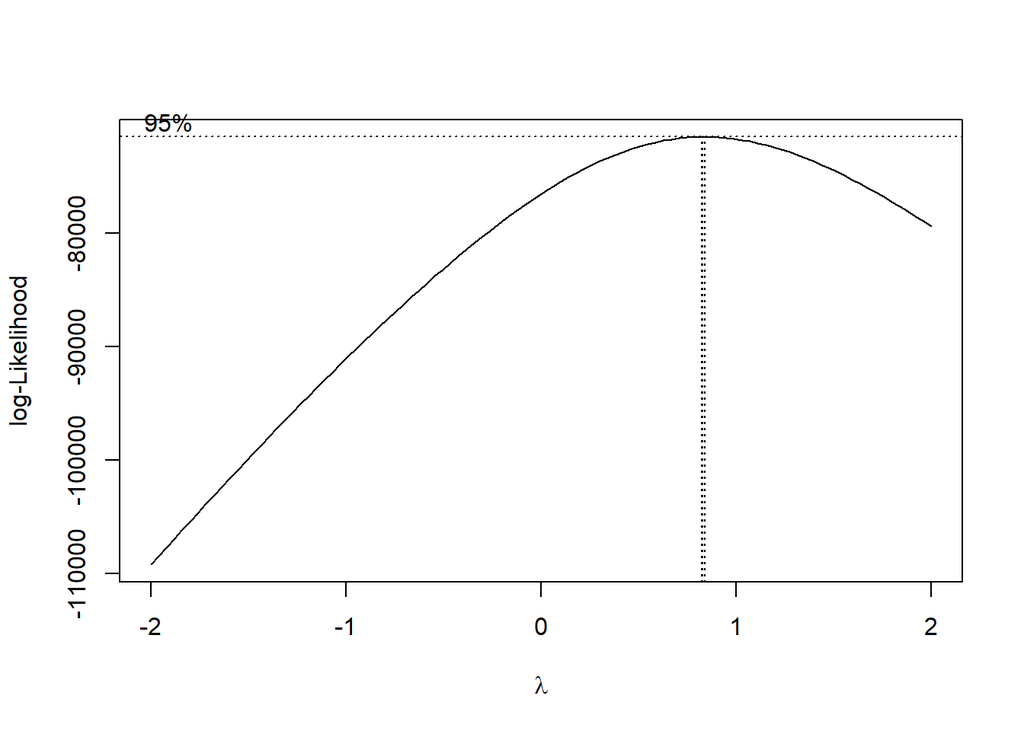

```r
boxcox_result <- boxcox(modelAIC, plotit = TRUE)
```

```r
lambda <- boxcox_result$x
log_likelihood <- boxcox_result$y

# Find the lambda with the maximum log-likelihood
best_lambda <- lambda[which.max(log_likelihood)]

# Print the best lambda
print(best_lambda)
```

```
## [1] 0.8282828
```

```r
# Build the final model with Box-Cox transformation
best_lambda = 1.5
model_cox = lm((((data_train$log_suicides_no^best_lambda) - 1)/best_lambda) ~
    year + transform_gdp_per_capita +
    transform_population + regionAsia + regionAfrica + regionNorthAmerica +
    regionSouthAmerica + sexMale + geneX + geneMillenials + geneBoomers +
    geneSilent + Age15to24 + Age25to34 + Age35to54 + Age55to74, data = data_train)
summary(model_cox)
```

```
##
## Call:
## lm(formula = (((data_train$log_suicides_no^best_lambda) - 1)/best_lambda) ~
##     year + transform_gdp_per_capita + transform_population +
##         regionAsia + regionAfrica + regionNorthAmerica + regionSouthAmerica +
##         sexMale + geneX + geneMillenials + geneBoomers + geneSilent +
##         Age15to24 + Age25to34 + Age35to54 + Age55to74, data = data_train)
##
## Residuals:
##     Min      1Q  Median      3Q     Max
## -6.0861 -1.2347  0.0246  1.2400  6.7164
##
## Coefficients:
##                            Estimate Std. Error t value Pr(>|t|)
## (Intercept)              -7.5002119  0.0796016 -94.222  < 2e-16 ***
## year                      0.0094358  0.0017820   5.295  1.2e-07 ***
## transform_gdp_per_capita  0.0060770  0.0006930   8.770  < 2e-16 ***
## transform_population      0.0703295  0.0002728 257.838  < 2e-16 ***
## regionAsia               -0.6156610  0.0384388 -16.017  < 2e-16 ***
## regionAfrica             -0.8608630  0.0925510  -9.302  < 2e-16 ***
## regionNorthAmerica       -0.7754588  0.0367520 -21.100  < 2e-16 ***
## regionSouthAmerica       -0.7861718  0.0459976 -17.092  < 2e-16 ***
## sexMale                   2.3842002  0.0263790  90.382  < 2e-16 ***
## geneX                    -2.8162367  0.0591711 -47.595  < 2e-16 ***
## geneMillenials           -3.7239452  0.0553341 -67.299  < 2e-16 ***
## geneBoomers              -1.5224463  0.0630634 -24.142  < 2e-16 ***
## geneSilent                0.4454278  0.0495391   8.991  < 2e-16 ***
## Age15to24                 3.2321189  0.0485617  66.557  < 2e-16 ***
## Age25to34                 3.0314198  0.0513927  58.985  < 2e-16 ***
## Age35to54                 2.5169117  0.0554241  45.412  < 2e-16 ***
## Age55to74                 1.1261165  0.0455653  24.714  < 2e-16 ***
## ---
## Signif. codes:  0 '***' 0.001 '**' 0.01 '*' 0.05 '.' 0.1 ' ' 1
##
## Residual standard error: 1.88 on 20339 degrees of freedom
## Multiple R-squared:  0.8272, Adjusted R-squared:  0.8271
## F-statistic:  6086 on 16 and 20339 DF,  p-value: < 2.2e-16
```

```r
lmtest::dwtest(model_cox)
```

```
##
##  Durbin-Watson test
##
## data:  model_cox
## DW = 1.9942, p-value = 0.34
## alternative hypothesis: true autocorrelation is greater than 0
```

```r
# Use Shapiro-Wilk test to test for normality of the residuals
set.seed(22) # For reproducibility
subsample_residuals <- sample(residuals(model_cox), size = 5000)
shapiro.test(subsample_residuals)
```

```
##
##  Shapiro-Wilk normality test
##
## data:  subsample_residuals
## W = 0.99943, p-value = 0.1286
```

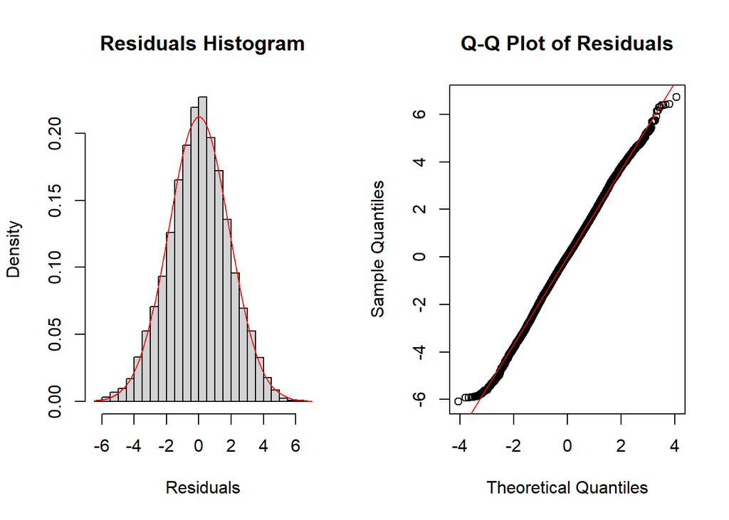

```r
# Plot residuals to visually check for normality
par(mfrow=c(1,2))

hist_residuals <- residuals(model_cox)
hist(hist_residuals, main = "Residuals Histogram", xlab = "Residuals", breaks = 30, probability = TRUE)

mean_residuals <- mean(hist_residuals)
sd_residuals <- sd(hist_residuals)
curve(dnorm(x, mean = mean_residuals, sd = sd_residuals), col = "red", add = TRUE)

qqnorm(hist_residuals, main = "Q-Q Plot of Residuals")
qqline(hist_residuals, col = "red")
```

```r
# Studentized Breusch-Pagan test for heteroscedasticity
bp_test <- lmtest::bptest(model_cox)
print(bp_test)
```

```
##
##  studentized Breusch-Pagan test
##
## data:  model_cox
## BP = 2943.8, df = 16, p-value < 2.2e-16
```

The BP statistic has decreased from 3230.76 to 2943.80 after the Box-Cox transformation. This suggests that the transformation has helped reduce heteroscedasticity, but it has not completely eliminated it.

Despite the decrease in the BP statistic, the p-value remains extremely small, indicating that heteroscedasticity is still a significant issue. The transformation has not fully addressed the non-constant variance in the residuals.

## 6. Prediction

###Using cross validation k-folds

```r
set.seed(1)
# Define a train control with k-fold cross-validation
train_control <- trainControl(method = "cv", number = 10)  # 10-fold cross-validation

# Define the formula for the model
formula <- as.formula(paste0("((log_suicides_no^", best_lambda, " - 1)/", best_lambda, ") ~
    year + transform_gdp_per_capita +
    transform_population + regionAsia + regionAfrica + regionNorthAmerica +
    regionSouthAmerica + sexMale + geneX + geneMillenials + geneBoomers +
    geneSilent + Age15to24 + Age25to34 + Age35to54 + Age55to74"))

# Train the model using the training data
cv_model <- train(formula, data = data_train, method = "lm", trControl = train_control)
```

```r
# Predict using the cross-validated model on the test data
predictions_log <- predict(cv_model, newdata = data_test)

# Calculate performance metrics on the test data
actual_values <- exp(data_test$log_suicides_no - 1) -1
predict_values <- round(exp((ifelse(predictions_log < 0, 0, predictions_log)  * best_lambda + 1)^(1/best_lambda) -1) -1, 2)
results <- data.frame(
  Actual = actual_values,
  Predicted = predict_values
)

# Print the results
print(results)
```

```
##       Actual Predicted
## 15         1      4.31
## 18         8     16.39
## 19         3     12.51
## 20         5     25.94
## 46         0      0.72
## 55         7     25.93
## 56         7     24.69
## 57         2     18.20
## 59         1      7.37
## 75         2      1.01
## 78         1      5.14
## 87        14     42.24
## 90        10     14.16
## 96         1      0.81
```

[output cut: 5076 more lines]

## 7. Evaluation

```r
# Calculate and print RMSE and R-squared
rmse <- sqrt(mean((results$Actual - results$Predicted)^2))
r_squared <- cor(results$Actual, results$Predicted)^2
cat("RMSE:", rmse, "\n")
```

```
## RMSE: 578.2537
```

```r
cat("R-squared:", r_squared, "\n")
```

```
## R-squared: 0.6606415
```